# DATA 551 Project

Yi Tang, Chenxi Yang

14/03/2020

## Introduction

Given three datasets about several aspects of three cars, including Saturn, Prius2007 and Prius2019. Regarding these datasets, we want to answer several questions using visualization by the package `ggplot2` in R.

For different issues, data is differently processed to statisfy the requirement of each question.

## Are there any obvious recording errors in the files?

While briefly observe the dataset, we see four errors among all three datasets.

Firstly, the most obvious error for three datasets is that there are several `NA`s involved. Three bar charts show the number of `NA` in each column in the datasets provided. We observe that there are respectively 10, 5 and 0 columns containing `NA` terms in Saturn.csv, Prius2007.csv and Prius2019.csv.

Thirdly, the error is in the column named `Gauge` in dataset Prius2019.csv. As we know the definition of `Gauge` is What the car reports as the number of 10ths of a tank at the time of the fill, which means all numbers in this column should be integers. However, we notice that there are two unnormal decimal points in the dataset. Therefore, we make a scatterplot to represent all observations and highlight the incorrect points in red color.

Lastlyly, for the column named `Station` in both Prius2007.csv and Prius2019.csv, there is one identical gas station that is labelled to two names `love` and `loves`, which are 5 and 3 observations respectively. In our later analysis, we convert `love` into `loves` to make the analysis more appropriate.

In order to continue further analysis, we remove the rows that have `NA` at each time using the columns and remove these unnormal records mentioned above and convert `love` to `loves`.

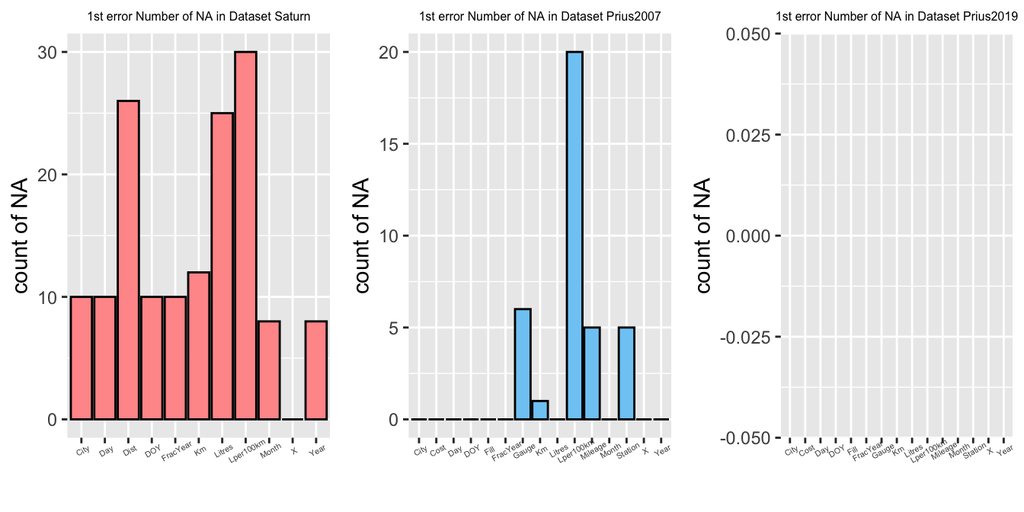

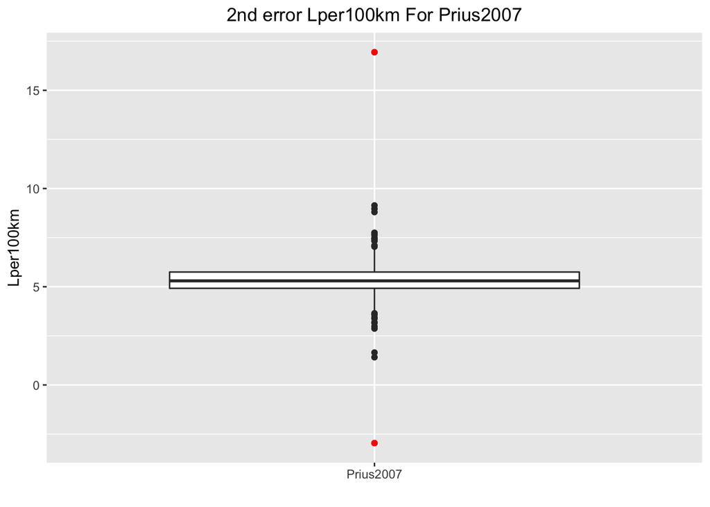

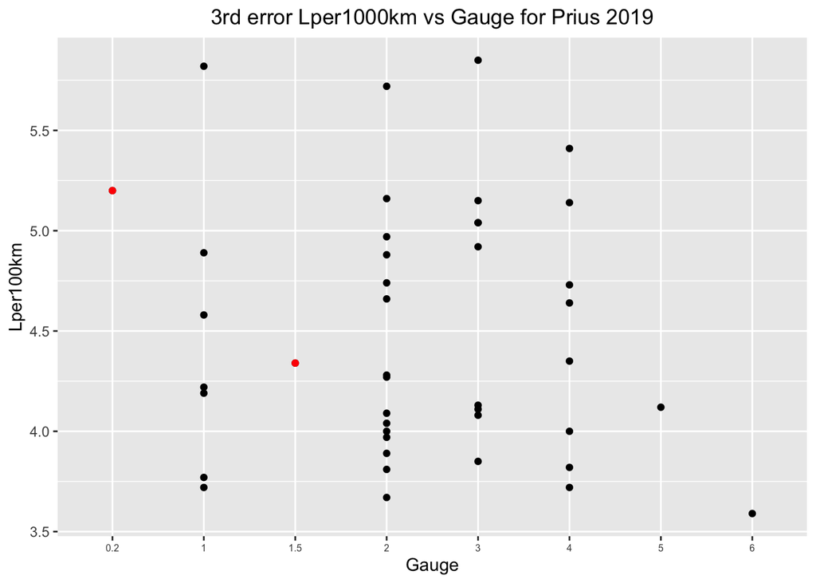

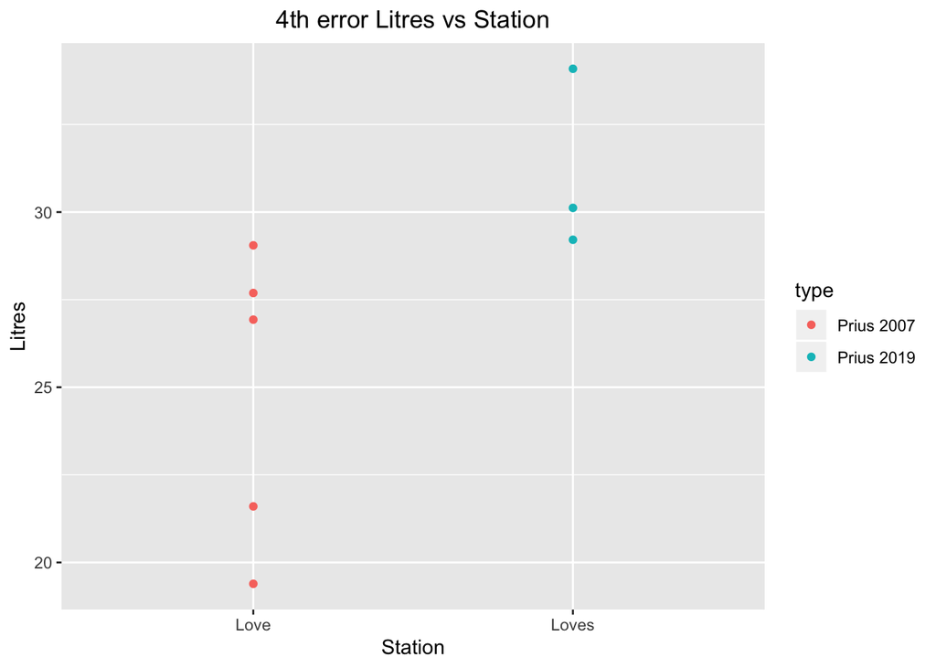

4 obvious recording errors

## Is “Mileage” accurate, or should I continue to calculate it myself?

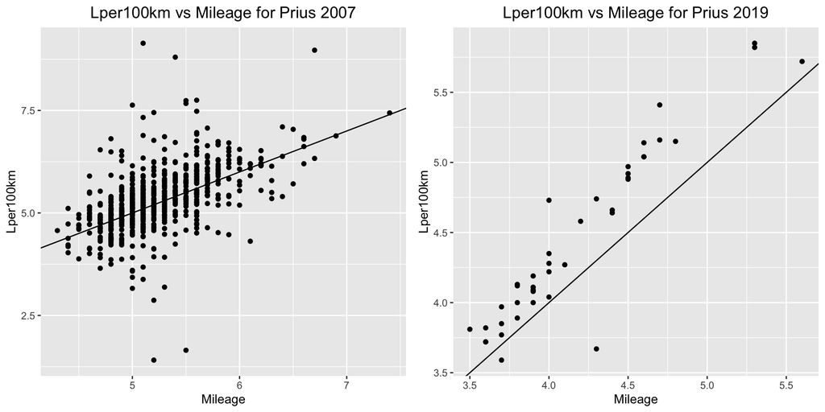

Yes, we should continue to calculate `mileage` ourselves. According to the scatterplot of mileage vs Lper100km, the points do not follow the regression line (y=x), which indicates at same situation, the number of mileage reported by the car is different to the number of litres per 100 kilometers calculated by ourselves. Therefore, we should calculate it manually.

## What variables appear to be related to fuel efficiency?

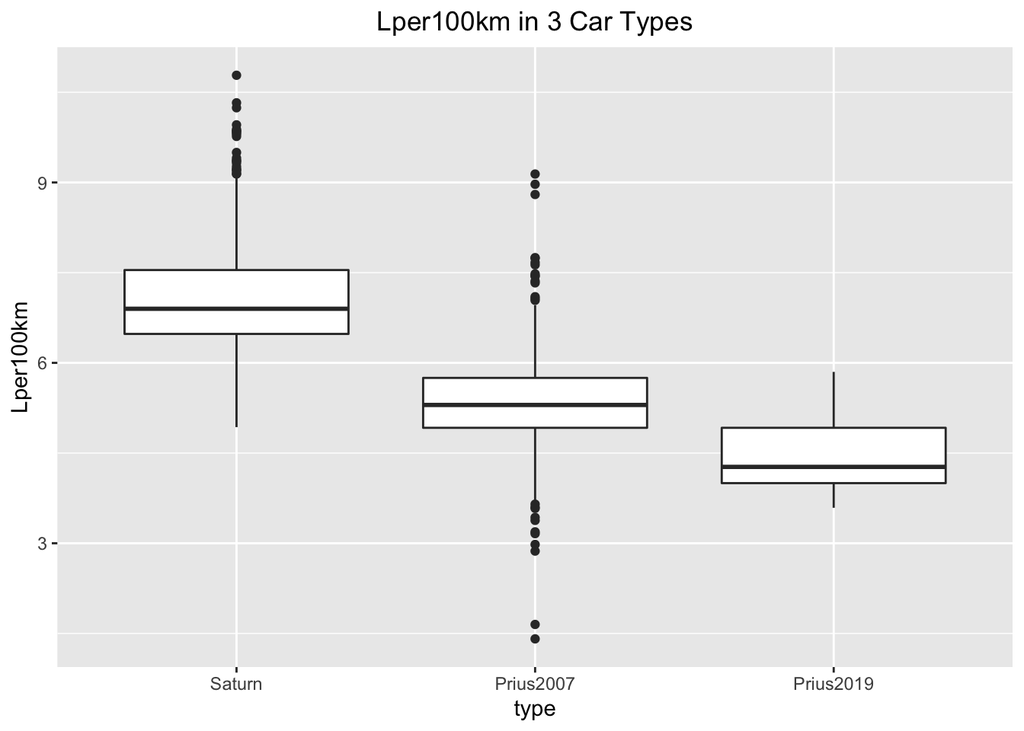

### The relationship between fuel efficiency and the car

According to the boxplot, we observe that Saturn has the largest median value of litres per 100 kilometers, followed by Prius2007 and Prius2019. As more litres used per 100 kilometers indicates lower fuel efficiency, so in this case, we can conclude that the newest car has higher fuel efficiency.

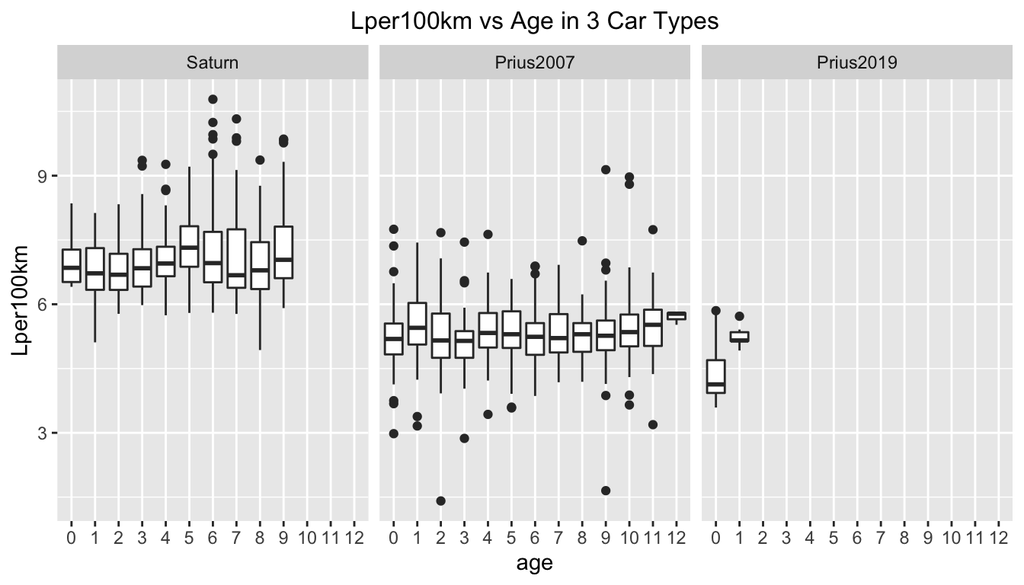

### The relationship between fuel efficiency and the age of the car

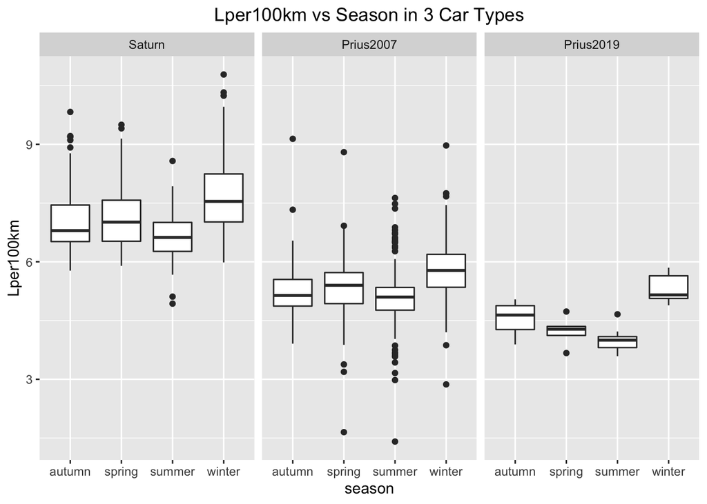

### The relationship between fuel efficiency and the season of the year

Regarding to the season, we divide 12 months into four seasons:

Spring: March, April and May Summer: June, July and August Autumn: September, October and November Winter: January, February and December

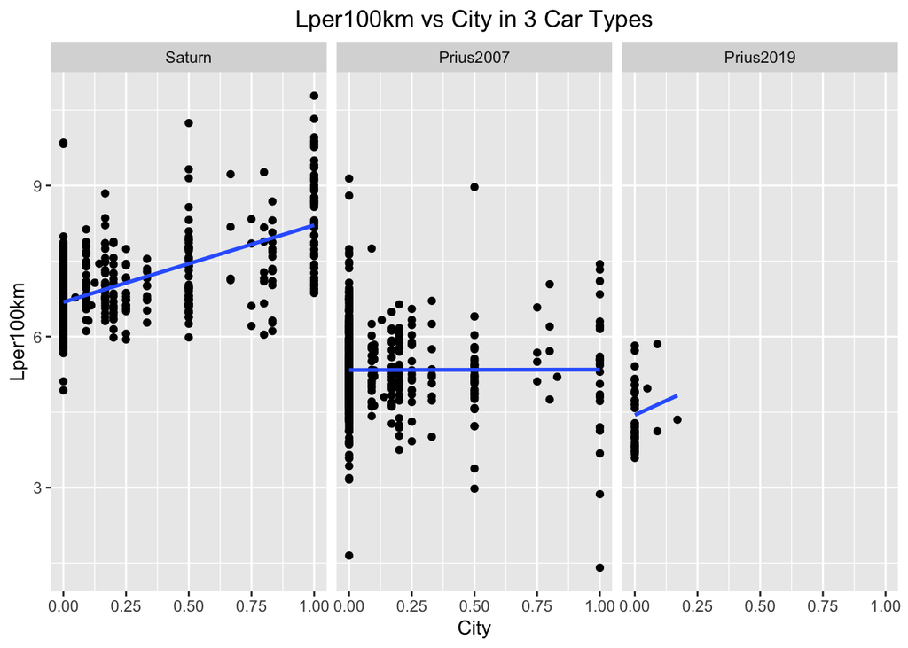

### The relationship between fuel efficiency and the city driving

According the scatterplots and regression lines below, we observe that for Saturn and Prius2019, along with the increase of city driving, more fuels are used per 100 kilometers, which indicates to the lower fuel efficiency. However, for Prius2007, the regression line seems straight. For different value of city driving, the fuel efficiency does not have much change.

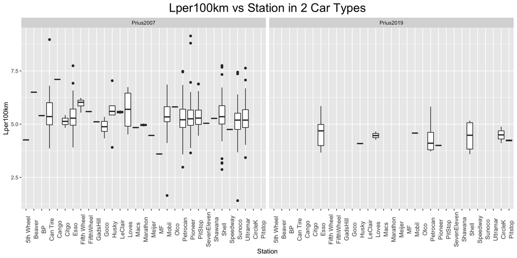

### The relationship between fuel efficiency and the brand of gasoline

As the brand of gasoline only exists in two datasets: Prius2007.csv and Prius2019.csv, so we extract these two columns from the original datasets.

According to the boxplot below, we observe that for different type of car, different brand of gasoline perform better.

For Prius2019, all nine brand seem to have relatively identical fuel efficiency.

[figure not shown]

## If the “Gauge” says I have 2/10 of a tank of gas, how much is really there?

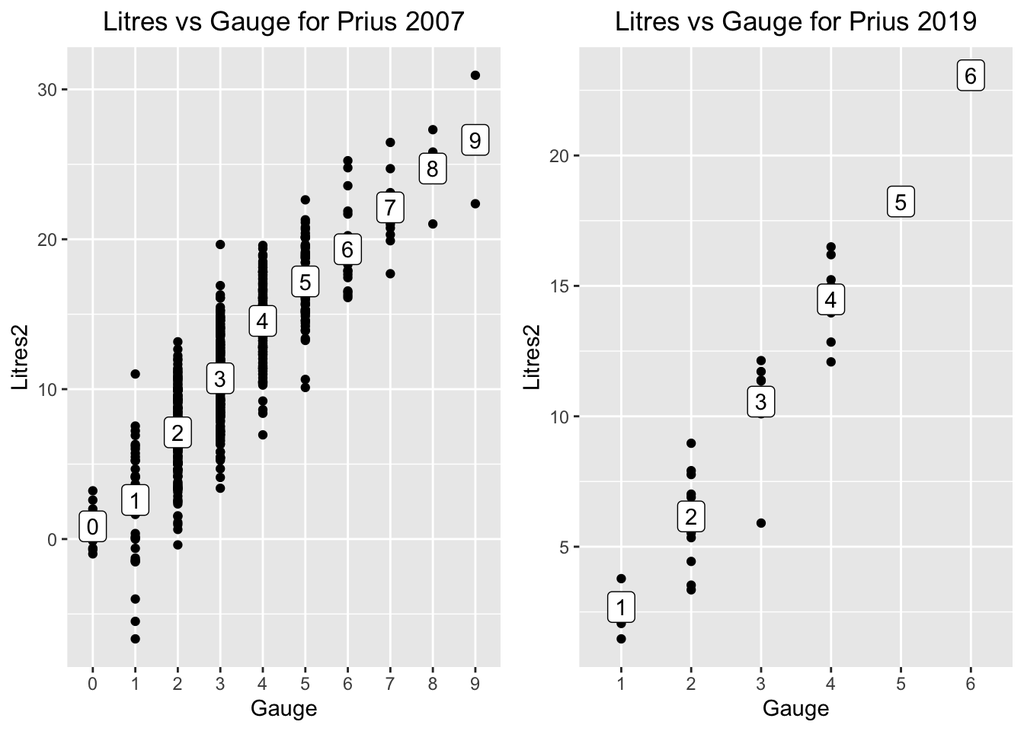

We extract the `Gauge` column from the Prius2007.csv and Prius2019.csv.

All labels on the plot indicate the mean litres of oil in the tank at that stage.

If we focus on 2/10 of a tank of gas, for Prius2007, there is nearly 7 (7.1181600) litres there, while for Prius2019, there is nearly 6 (6.160955) litres there.

## Does the fuel efficiency change along with the increase of kilometers?

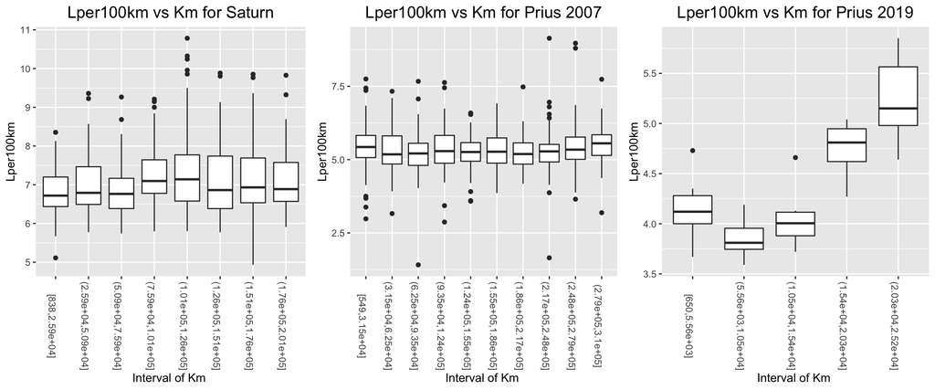

We divide the total number of kilometers into several intervals for each car.

For Prius2007, we divide the total number of kilometers into 10 intervals. We observe that the fuel efficiency does not have a significant change over time.

## The relationship between month and the fuel consumption

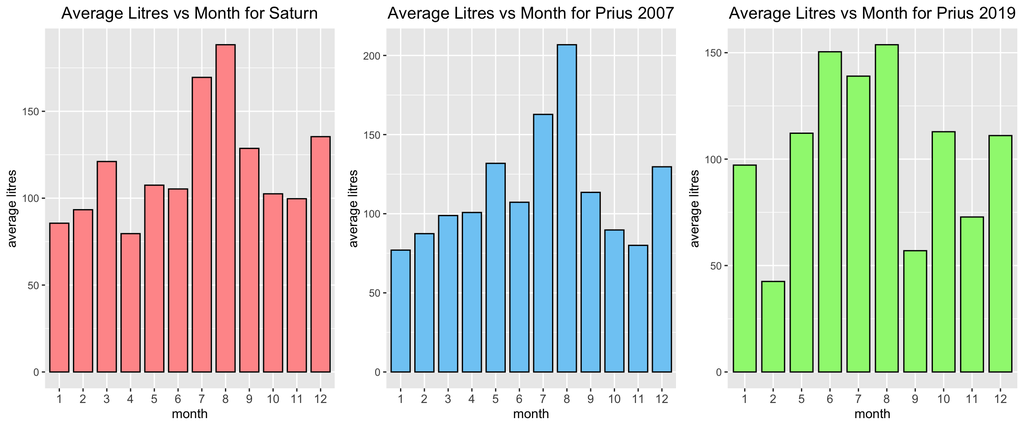

## Conclusion

In this project, we analyze 6 questions, including the obvious recording errors in the files, the accuracy of “mileage”, variables related to fuel efficiency, real values of “Gauge”, the fuel efficiency changes along with the increase of kilometers and the relationship between month and the fuel consumption.